# Mathematical Expectation

STAT 4714

Author

Michael Schwob

# 1 Mean of a Random Variable

## 1.1 Mean of $X$

We are often interested in computing the **mean of a random variable $X$**. The mean is also called the **mathematical** **expectation** or **expected value** of $X$, denoted $E(X)$ or $\mu_x$.

- *Ex*: In communications, the expected value can tell us the long-term average power that a receiver must handle; this information could inform the design of amplifiers, filters, and error-control codes.
- *Ex*: Electrical engineers often design circuits and receivers around the expected DC level (bias) of signals, not just instantaneous voltage.

## 1.2 Definition of $E(X)$

Let $X$ be a random variable with probability distribution $f(x)$. The **mean** or **expected value** of $X$ is
$$\mu=E(X)=\sum_x xf(x)$$
if $X$ is discrete, or
$$\mu=E(X)=\int^\infty_{-\infty}xf(x)\,dx$$
if $X$ is continuous.

## 1.3 Intuition Behind $E(X)$

Consider an experiment in which a fair coin was tossed twice. Then, $S=\{HH,HT,TH,TT\}$. Let $X$ denote the number of heads, taking on the values $0,1,$ or $2$. Because each outcome is equally likely in $S$, then we know $P(X=0)=P(TT)=1/4$, $P(X=1)=P(TH)+P(HT)=1/2$, and $P(X=2)=P(HH)=1/4$.

We can find $E(X)$ by knowing the chance that each possible value of $X$ has of occurring:
$$E(X)=(0)(1/4) + (1)(1/2) + (2)(1/4)=1.$$

## 1.4 Notes on Expectation

The route to computing $E(X)$ is different than how we computed the sample mean $\bar{X}$ in the past. The sample mean is obtained using data, whereas the expected value is calculated using the probability distribution.

Also, note that the expected value can be a number that is not a possible outcome for the experiment.

- *Ex*: Consider flipping an unfair coin with $P(H)=0.60$ and $X$ denotes the number of heads. Then, $E(X)=1.2$, which is not possible to actually observe.

## 1.5 Ex: Component Reliability

A lot containing 7 components is sampled by a quality inspector. The lot contains 4 good components and 3 defective components. A random sample of 3 components is taken by the inspector. Find the expected value of the number of good components in this sample.

- Let $X$ denote the number of good components with PDF
  $$f(x)=\frac{\binom{4}{x}\binom{3}{3-x}}{\binom{7}{3}},\quad x=0,1,2,3.$$

## 1.6 Ex: Component Reliability

A lot containing 7 components is sampled by a quality inspector. The lot contains 4 good components and 3 defective components. A random sample of 3 components is taken by the inspector. Find the expected value of the number of good components in this sample.

- Then,
  $$E(X)=\sum_{x=0}^3xf(x)=0f(0)+1f(1)+2f(2)+3f(3)=1.7$$

## 1.7 Ex: Component Lifetime

Let $X$ be the random variable that denotes the life in hours of a certain electronic device. The PDF is
$$f(x)=\frac{20000}{x^3},\quad x>100.$$
Find the expected life of this type of device.

- Using the definition of mathematical expectation,
  $$\mu=E(X)=\int_{100}^\infty x \underbrace{\frac{20000}{x^3}}_{f(x)}\,dx
  =\int^\infty_{100}20000x^{-2}\,dx=200.$$

## 1.8 Expectation of a Function of a Random Variable

In many cases, there may be interest in the expected value of a function of a random variable, denoted $E[g(X)]$ where $g(X)$ is the function of the random variable $X$.

- *Ex*: Let $X$ be a random variable for the received voltage. Then, power is $g(X)=X^2$, and we’d want to find $E(X^2)$.
- *Ex*: Let $Y$ be a random variable for the instantaneous signal-to-noise ratio (SNR). We might want to know the average channel capacity (bit/s/Hz) of a noisy channel, so we compute $E[g(Y)]$, where $g(Y)=\log_2(1+Y)$.

## 1.9 Expectation of a Function of a Random Variable

Let $X$ be a random variable with probability distribution $f(x)$. The expected value of the random variable $g(X)$ is
$$\mu_{g(X)}=E[g(X)]=\sum_x g(x)f(x)$$
if $X$ is discrete and, if $X$ is continuous,
$$\mu_{g(X)}=E[g(X)]=\int^\infty_{-\infty}g(x)f(x)\,dx.$$

## 1.10 Ex: Function of a Continuous Random Variable

Let $X$ be a random variable with density function
$$f(x)=x^2/3,\quad -1<x<2.$$
Find the expected value of $g(X)=4X+3.$

- We know that $E[g(X)]=\int^\infty_{-\infty}g(x)f(x)\,dx$, so we solve
  $$E[g(X)]=\int^2_{-1}(4x+3)(x^2/3)\,dx=8.$$

## 1.11 An Extension for the Joint PDF

Let $X$ and $Y$ be random variables with joint probability distribution $f(x,y)$. The expected value of the random variable $g(X,Y)$ is
$$\mu_{g(X,Y)}=E[g(X,Y)]=\sum_x\sum_y g(x,y)f(x,y)$$
if $X$ and $Y$ are discrete and, if $X$ and $Y$ are continuous,
$$\mu_{g(X,Y)}=E[g(X,Y)]=\int^\infty_{-\infty}\int^\infty_{-\infty}g(x,y)f(x,y)\,dx\,dy.$$

## 1.12 Ex: Function of a Joint Distribution

Find $E(Y/X)$ for the density function
$$f(x,y)=\frac{x(1+3y^2)}{4}, \quad 0<x<2, \; 0 < y < 1.$$

- Apply the definition on the previous slide:
  $$E(Y/X)=\int^1_0\int^2_0\frac{y}{x}\cdot\frac{x(1+3y^2)}{4}\,dx\,dy=\frac58.$$

## 1.13 Breakout Groups

*See Ch4-BO1*

# 2 Variance and Covariance of Random Variables

## 2.1 Another Important Piece of Information

Earlier, we discussed how sample means only provide a bit of information; sample variances provide additional information. The same concept is true here: knowing the variability of random variables is incredibly important.

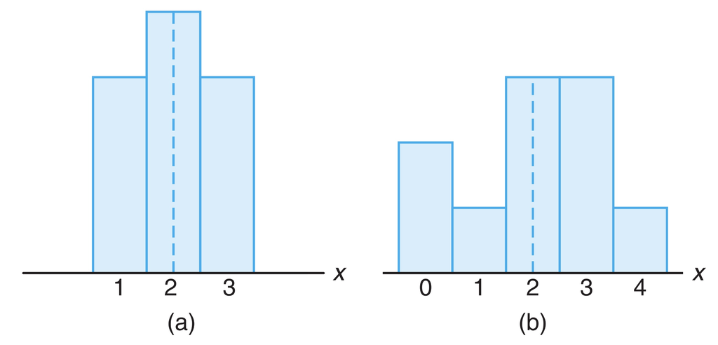

## 2.2 Variance of a Random Variable

Let $X$ be a random variable with probability distribution $f(x)$ and mean $\mu$. The **variance** of $X$ is
$$\sigma^2=E[(X-\mu)^2]=\sum_x(x-\mu)^2 f(x)$$
if $X$ is discrete, and
$$\sigma^2=E[(X-\mu)^2]=\int_{-\infty}^\infty (x-\mu)^2 f(x)\,dx$$
if $X$ is continuous. The **standard deviation** of $X$ is $\sigma=\sqrt{\sigma^2}$.

## 2.3 An Alternative Formula

Perhaps the easiest way to compute the variance of a random variable is to use the following formula:
$$\sigma^2=E(X^2)-E(X)^2=E(X^2)-\mu^2.$$

$$\begin{align*}
\text{Proof: }\sigma^2 &= \sum_x(x-\mu)^2f(x)=\sum_x(x^2-2\mu x+\mu^2)f(x)\\
&= \sum_x x^2f(x)-2\mu\sum_xxf(x)+\mu^2\sum_xf(x)\\
&= E(X^2) - 2\mu(\mu)+\mu^2(1) = E(X^2)-\mu^2
\end{align*}$$

## 2.4 Ex: Defective Parts

Let $X$ denote the number of defective parts for a machine when 3 parts are sampled from a production line. The following is the probability distribution of $X$. Find $\sigma^2_X$.

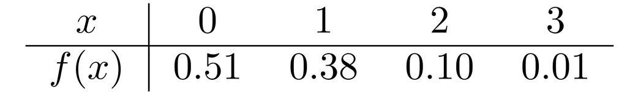

- We’ll want to use $\sigma^2=E(X^2)-E(X)^2$, so let’s compute $E(X)$:
  $$E(X)=0(0.51)+1(0.38)+2(0.10)+3(0.01)=0.61.$$

## 2.5 Ex: Defective Parts

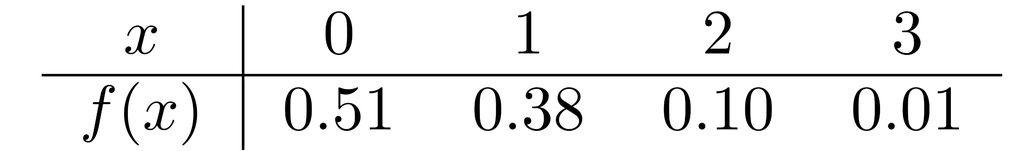

- Then, we need to compute $E(X^2)$:
  $$E(X^2)=0^2(0.51)+1^2(0.38)+2^2(0.10)+3^2(0.01)=0.87.$$
  Therefore, the variance is
  $$\sigma^2=0.87-0.61^2=0.4979.$$

## 2.6 Variance of a Function of a Random Variable

Let $X$ be a random variable with probability distribution $f(x)$. The variance of the random variable $g(X)$ is
$$\sigma^2_{g(X)}=E\{[g(X)-\mu_{g(X)}]^2\}=\sum_x[g(x)-\mu_{g(X)}]^2 f(x)$$
if $X$ is discrete and, if $X$ is continuous,
$$\sigma^2_{g(X)}=E\{[g(X)-\mu_{g(X)}]^2\}=\int^\infty_{-\infty}[g(x)-\mu_{g(X)}]^2 f(x)\,dx.$$

## 2.7 Ex: Variance of a Function of a Random Variable

Let $X$ be a random variable that has the density function
$$f(x)=x^2/3,\quad -1<x<2.$$
Find the variance of $g(X)=4X+3.$

- Note that we previously found $\mu_{4X+3}=8$, so
  $$E[(4X+3-8)^2]=E[(4X-5)^2]
  =\int^2_{-1}(4x-5)^2\frac{x^2}{3}\,dx=\frac{51}{5}.$$

## 2.8 Covariance of Random Variables

- Let $X$ and $Y$ be random variables with joint probability distribution $f(x,y)$. An important piece of information can be obtained by taking the expected value of the function $g(X,Y)=(X-\mu_x)(Y-\mu_Y)$, called the **covariance**.
- The covariance between two random variables measures the nature of the association between the two. Importantly, the *sign* of the covariance indicates whether the two random variables are positively or negatively related.

## 2.9 Covariance of Random Variables

Let $X$ and $Y$ be random variables with joint probability distribution $f(x,y)$. The **covariance** of $X$ and $Y$ is
$$\sigma_{XY}=E[(X-\mu_X)(Y-\mu_Y)]=\sum_x\sum_y(x-\mu_X)(y-\mu_Y)f(x,y)$$
if $X$ and $Y$ are discrete, and
$$\sigma_{XY}=\int^\infty_{-\infty}\int^\infty_{-\infty}(x-\mu_X)(y-\mu_Y)f(x,y)\,dx\,dy$$
if $X$ and $Y$ are continuous.

## 2.10 An Alternative (Easier) Formula

The covariance of two random variables $X$ and $Y$ with means $\mu_X$ and $\mu_Y$, respectively, is given by
$$\sigma_{XY}=E(XY)-\mu_X\mu_Y.$$

- *A couple notes on covariance & dependence:* When $X$ and $Y$ are statistically independent, then the covariance is 0. The converse is not generally true. The covariance describes the linear relationship between $X$ and $Y$. If their covariance is 0, they could still have a nonlinear relationship and hence are still dependent.

## 2.11 Ex: Marathon Runners

The fraction $X$ of male runners and $Y$ of female runners who compete in marathon races are described by the joint density function
$$f(x,y)=8xy,\quad 0\le y\le x \le 1.$$
Find the covariance of $X$ and $Y$.

- Roadmap: To compute $\sigma_{XY}=E(XY)-E(X)E(Y)$, we find $E(X)$ and $E(Y)$ by computing the marginal distributions $g(x)$ and $h(y)$, then solving for $E(X)$ and $(Y)$. Next, we compute $E(XY)$ and, finally, $\sigma_{XY}=\frac{4}{225}.$

## 2.12 Correlation Coefficient

- The **covariance** provides some information regarding the relationship between $X$ and $Y$; importantly, the sign tells us whether the relationship is positive or negative. However, $\sigma_{XY}$ does not tell us how strong the relationship is because $\sigma_{XY}$ is not *scale-free* (i.e., the magnitude depends on the units measured for $X$ and $Y$).
- Instead, we use the **correlation coefficient** to quantify the strength of the relationship between $X$ and $Y$. This correlation coefficient is essentially a scale-free version of the covariance.

## 2.13 Correlation Coefficient (definition)

Let $X$ and $Y$ be random variables with covariance $\sigma_{XY}$ and standard deviations $\sigma_X$ and $\sigma_Y$, respectively. The correlation coefficient of $X$ and $Y$ is
$$\rho_{XY}=\frac{\sigma_{XY}}{\sigma_X\sigma_Y}.$$

Note that $\rho_{XY}$ is free of the units of $X$ and $Y$, and it satisfies the inequality $-1\le\rho_{XY}\le 1.$

## 2.14 Ex: Marathon Runners’ $\rho_{XY}$

Find the correlation coefficient of $X$ and $Y$ when
$$f(x,y)=8xy,\quad 0\le y\le x \le 1.$$

- To compute the standard deviations $\sigma_X$ and $\sigma_Y$, we need
  $$E(X^2)=\int^1_0 x^2g(x)\,dx=2/3 \quad \text{and} \quad E(Y^2)=1/3.$$
  Then, we compute $\sigma^2_X=2/75$ and $\sigma^2_Y=11/225$ to get
  $$\rho_{XY}=(4/225)/\sqrt{(2/75)(11/225)}=4/\sqrt{66}.$$

## 2.15 Breakout Groups

*See Ch4-BO2*

# 3 Means and Variances of Linear Combinations of Random Variables

## 3.1 Univariate Results

**Expectation of $aX+b$**
If $a$ and $b$ are constants, then
$$E(aX+b)=aE(X)+b.$$

**Expectation of Sums of Functions of a Random Variable**
The expected value of the sum or difference of two or more functions of a random variable $X$ is the sum or difference of the expected values of the functions:
$$E[g(X) \pm h(X)]=E[g(X)]\pm E[h(X)].$$

## 3.2 Multivariate Results

**Expectation of Sums of Functions of Random Variables**
The expected value of the sum or difference of two or more functions of random variables $X$ and $Y$ is the sum or difference of the expected values of the functions:
$$E[g(X,Y) \pm h(X,Y)]=E[g(X,Y)]\pm E[h(X,Y)].$$

**Corollary #1**
Setting $g(X,Y)=g(X)$ and $h(X,Y)=h(Y)$, we see that
$$E[g(X) \pm h(Y)]=E[g(X)]\pm E[h(Y)].$$

## 3.3 Multivariate Results

**Corollary #2**
Setting $g(X,Y)=X$ and $h(X,Y)=Y$, we see that
$$E[X \pm Y]=E[X]\pm E[Y].$$

**Independent Random Variables**
Let $X$ and $Y$ be two independent random variables. Then,
$$E(XY)=E(X)E(Y).$$

## 3.4 Ex: Microchip Chemical Ratios

Suppose we want to know if the ratio of gallium to arsenide affects the functioning of gallium-arsenide wafers, which are (were?) the main components of microchips. Let $X$ denote the ratio of gallium to arsenide and $Y$ denote the functional wafers retrieved during a 1-hour period with joint PDF
$$f(x,y)=x(1+3y^2)/4,\quad 0<x<2, \; 0<y<1.$$
Determine if $X$ and $Y$ are independent.

## 3.5 Variance of a Linear Combination of Random Variables

If $X$ and $Y$ are random variables with joint probability distribution $f(x,y)$ and $a$, $b$, and $c$ are constants, then
$$\sigma^2_{aX+bY+c}=a^2\sigma^2_X+b^2\sigma^2_Y+2ab\sigma_{XY}.$$

- Note that the variance is unchanged if a constant is added to or subtracted from a random variable. The addition or subtraction of a constant simply shifts the values of $X$ to the right or left; it doesn’t change their variability.

## 3.6 Variance under Independence

For $n$ independent random variables $X_1,\dots,X_n$, we have
$$\sigma^2_{a_1X_1+\dots+a_nX_n}=a_1^2\sigma^2_{X_1}+\dots+ a_n^2\sigma^2_{X_n}.$$

*Ex:* Let $X$ and $Y$ denote the amounts of two different types of impurities in a batch of a certain chemical product. Suppose that $X$ and $Y$ are independent random variables with variances $\sigma^2_X=2$ and $\sigma^2_Y=3$. Find the variance of the random variable $Z=3X-2Y+5.$

- $\sigma^2_Z = \sigma^2_{3X-2Y+5} = \sigma^2_{3X-2Y}= 9\sigma^2_X+4\sigma^2_Y= 9(2)+4(3)=30.$

# 4 Chebyshev’s Theorem

## 4.1 Relating an Interval to $\sigma$

Russian mathematician P. L. Chebyshev (1821–1894) found that the fraction of the area between any two values that are symmetrically centered on the mean is related to the standard deviation. As a result, he established the following theorem:

- The probability that any random variable $X$ will assume a value within $k$ standard deviations of the mean is at least $1-1/k^2$:
  $$P(\mu-k\sigma<X<\mu+k\sigma)\ge 1-\frac{1}{k^2}.$$

## 4.2 Ex: Chebyshev’s Theorem

A random variable $X$ has mean $\mu=8$, variance $\sigma^2=9$, and an unknown probability distribution. Find the lower-bound for $P(-4<X<20)$.

- Note that
  $$P(-4 <X<20)=P(8 - 4(3)<X<8+4(3))\ge 15/16.$$

[figure not shown]

## 4.3 Ex: Chebyshev’s Theorem

A random variable $X$ has mean $\mu=8$, variance $\sigma^2=9$, and an unknown probability distribution. Find the upper-bound for $P(|X-8| \ge 6)$.

- Note that
  $$P(|X-8|\ge 6)=1-P(|X-8|<6)=1-P(-6<X-8<6).$$
  Rearranging, we see that
  $$P(|X-8|\ge 6)=1-P[8-2(3)<X<8+2(3)] \le \frac14.$$

## 4.4 Notes on Chebyshev’s Theorem

- This theorem provides a conservative estimate of the probability that a random variable assumes a value within $k$ standard deviations of its mean for any real number $k$.
- This theorem holds for any distribution of observations; we say that it’s *distribution-free*. For this to occur, it must be a *weak* result. Additionally, the only value provided is a lower bound.
- Only when the probability distribution is known can we determine exact probabilities. Otherwise, Chebyshev’s Theorem gives us a decent guess.

## 4.5 An Alternative: The Empirical Rule (68-95-99.7 Rule)

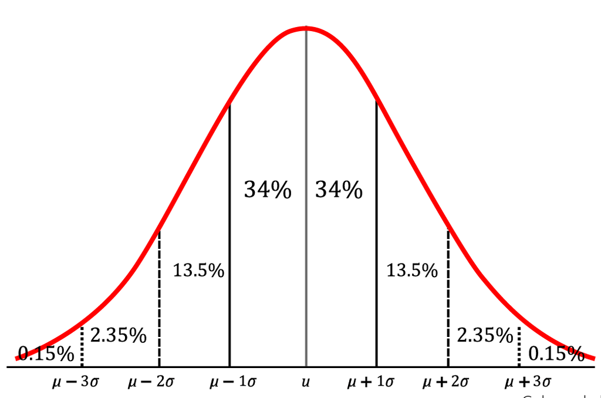

- Only works for distributions that are bell-shaped
- Provides tighter percentages than Chebyshev’s Theorem

## 4.6 Breakout Groups

*See Ch4-BO3*